# Assignment 7

Liam

10/16/2019

## Questions

```r
library(ggplot2)
library(tidyverse)
library(readxl)
library(GGally)
```

1. Write a function: input a number x and return $x^2+3x+1$

```r
func1<- function(x){
  x^2+3*x+1
}
```

2. Not using loops, write a function: input a vector and return the product of all the entries in the vector.

```r
vectprod<-function(x){
  prod(x)
}
q<-c(1,2,NA,4,5,6,7)
vectprod(q)
```

```
## [1] NA
```

3. Using loops, write a function: input a vector and return the product of all the entries in the vector.

```r
vectprod2<-function(x) {
  c=1
  for (i in x) {
    c=i*c
  }
  return(c)
}
vectprod2(q)
```

```
## [1] NA
```

**User defined functions combining with `apply` function.** The `apply` function returns a vector or array or list of values obtained by applying a function to margins of an array or matrix. For example, to calculate the column means of a matrix, one can use the `apply` function as follows.

```r
x = matrix(c(1:9), nrow=3)
x
```

```
##      [,1] [,2] [,3]
## [1,]    1    4    7
## [2,]    2    5    8
## [3,]    3    6    9
```

```r
apply(x, MARGIN=2, mean)
```

```
## [1] 2 5 8
```

```r
apply(x, MARGIN=1, sd)
```

```
## [1] 3 3 3
```

In the above examples, we use the `mean` function to apply to columns. There are some other similar bultin functions that works with `apply` such as `sum`, `median`, `sd` (for standard deviation). We can also use user-defined functions instead of these builtin functions. For examle, if one wants to take the sum of the `sine` columns wise, one can do as follows.

```r
f = function(w)
{
  return(sum(sin(w)))
}

apply(x, MARGIN = 2, f)
```

```
## [1]  1.891888 -1.995142  2.058463
```

In the above codes, function $f$ is applied to each columns of $x$. This codes can be shorten using **anonymous functions**, i.e. functions with nonames, as

```r
apply(x, 2, function(w){sum(sin(w))})
```

```
## [1]  1.891888 -1.995142  2.058463
```

In the above code, we write a function directly with the `apply` function this function does not need a name, also called **anonymous functions**.

4. Use the above approach to write to caculate or plot
- 1. the rows sum squares of matrix $x$ above.

```r
apply(x, 1, function(x){
  sum(x)^2
})
```

```
## [1] 144 225 324
```

- 2. the row sums of positive entries in $y$, where $y$ is a 100x100 matrix with the entries following standard normal distribution.

```r
y=matrix(rnorm(100*100, mean=0, sd=1), 100, 100)
apply(y, 1, function(x){sum(x[which(x>0)])})
```

```
##   [1] 38.77454 32.90192 31.28976 35.49669 33.45498 45.92308 42.45985
##   [8] 33.03820 28.88693 45.96411 39.63428 37.92502 29.62488 30.59378
##  [15] 36.38308 38.69521 45.18255 32.81558 46.64664 33.81159 40.66976
##  [22] 34.87669 35.66106 39.72016 44.09790 41.81018 28.25457 40.45283
##  [29] 46.13013 32.14607 43.82053 41.25878 44.79488 33.79947 38.98817
##  [36] 51.12440 43.53326 37.74635 30.28067 34.04841 33.33364 29.14313
##  [43] 33.53174 33.99491 45.92796 36.46218 35.01874 42.79110 39.86254
##  [50] 42.00085 40.35199 32.64586 43.82561 38.93940 39.52625 40.30269
##  [57] 29.87858 44.27870 44.39450 28.21020 31.27094 41.47130 34.80051
##  [64] 47.92527 44.73046 47.09323 35.84894 29.57983 32.02279 38.45733
##  [71] 51.18774 49.59545 33.15516 43.53469 32.38168 49.16070 34.16972
##  [78] 33.79232 32.62370 34.86280 40.68819 42.10425 41.46053 42.25104
##  [85] 42.08352 38.19290 33.64861 34.13117 37.48650 30.19607 30.74853
##  [92] 32.77593 37.84126 37.05411 45.43577 48.12830 30.38746 33.27957
##  [99] 39.13516 42.77206
```

- 3. the row sums square of entries in $y$, where $y$ is a 100x100 matrix with the entries following standard normal distribution. What is the distribution of these sum squares?

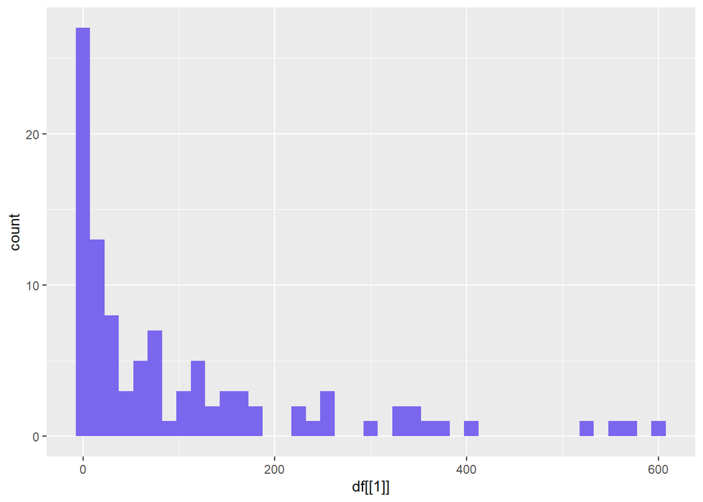

```r
df<-data.frame(apply(y, 1, function(x){sum(x)^2}))
df%>%
  ggplot(aes(x=df[[1]]))+
  geom_histogram(binwidth=15, fill="slateblue2")
```

- 4. the historgrams for each rows in $z$, where $z$ is a 3x1000 matrix with the entries following standard normal distribution.

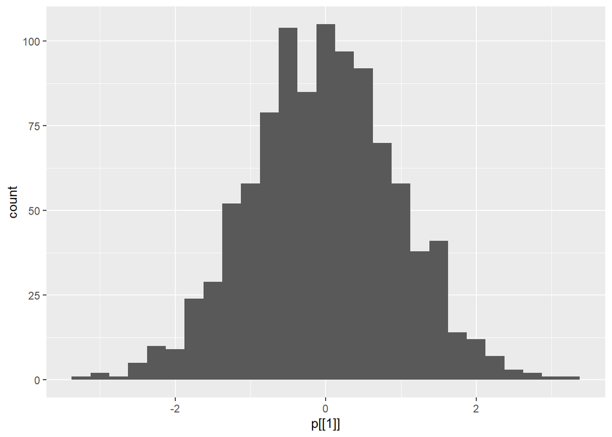

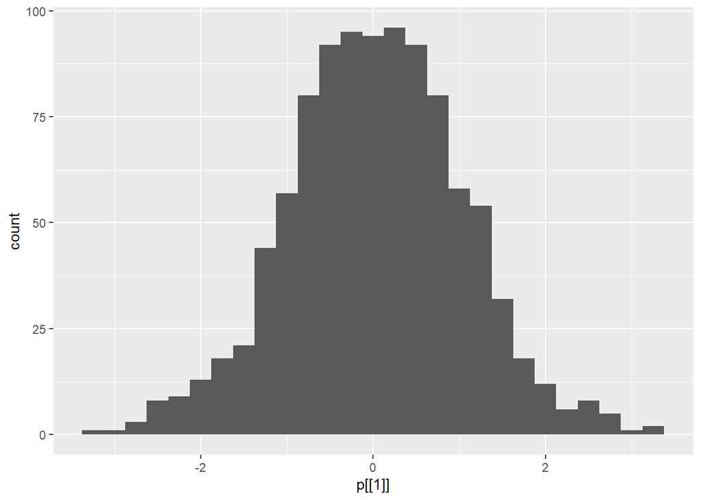

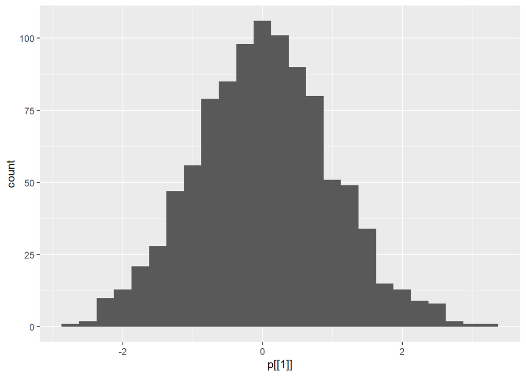

```r
z<-matrix(rnorm(3*1000, mean=0, sd=1), 3, 1000)
apply(z, 1, function(x){
  p=data.frame(x)
  ggplot(p, aes(x=p[[1]]))+geom_histogram(binwidth=0.25)})
```

5. Write a function:
- input a vector $v$ and a value $n$
- out the original vector with its missing data in $v$ being replaced by $n$.

```r
q<-c(1,2,NA,4,5,6,7)
datareplace<-function(v,n){
  if (sum(is.na(v))==0)
    print('There is no missing value')
  else
    v[is.na(v)]<-n
    v
}
datareplace(q, 17)
```

```
## [1]  1  2 17  4  5  6  7
```

```r
q<-datareplace(q,17)
datareplace(q)
```

```
## [1] "There is no missing value"
```

```
## [1]  1  2 17  4  5  6  7
```

$v$ could be a numeric or characrer vector and $n$ could be a number or a string. If there is no missing value, return $v$ and the message `There is no missing value.`

6. Write a function:
- input a numeric vector
- output the original vector with its missing data being replaced by the mean of the vector. If there is no missing value, return the original vector with the message `There is no missing value.`

```r
q<-c(1,2,NA,4,5,6,7)
replacewmean<-function(v){
  if (sum(is.na(v))==0)
    print('There is no missing value')
  else
    v[is.na(v)]<-mean(v, na.rm=TRUE)
    v
}
replacewmean(q)
```

```
## [1] 1.000000 2.000000 4.166667 4.000000 5.000000 6.000000 7.000000
```

```r
q<-replacewmean(q)
replacewmean(q)
```

```
## [1] "There is no missing value"
```

```
## [1] 1.000000 2.000000 4.166667 4.000000 5.000000 6.000000 7.000000
```

7. Write a function:
- input a character/factor vector
- output a vector with its missing data being replaced by the mode of the vector. If there is no missing value, return the original vector with the message `There is no missing value.`

```r
q<-c('z','z',NA,'s','s','s','d')
getmode <- function(x) {
  ux <- na.omit(unique(x))
 tab <- tabulate(match(x, ux)); ux[tab == max(tab) ]
}

replacewmode<-function(v){
  if (sum(is.na(v))==0)
    print('There is no missing value')
  else
    v[is.na(v)]<-getmode(v)
    v
}
replacewmode(q)
```

```
## [1] "z" "z" "s" "s" "s" "s" "d"
```

```r
q<-replacewmode(q)
replacewmode(q)
```

```
## [1] "There is no missing value"
```

```
## [1] "z" "z" "s" "s" "s" "s" "d"
```

8. Write a function:
- input a data frame
- output the data frame with numeric missing values being replaced by the corresponding column mean and categorical missing values being replaced by the corresponding column mode.

```r
titanic<-read_csv("C:\\Users\\student\\Desktop\\Fall2019\\R\\titanic.csv")
titanic<-data.frame(titanic)
question8<- function(n){
  titanic1<- n %>%
    select_if(is.numeric)
  titanicmean<- apply(titanic1, 2, mean, na.rm=TRUE)
  out1<- titanic1%>%
    replace_na(list(titanicmean))
  titanic2<- n %>%
    select_if(is.character)
  titanicmode<-apply(titanic2,2,getmode)
  out2<- titanic2%>%
    replace_na(list(titanicmode))
  out<- bind_cols(out1,out2)
  return(out)
}
out <- question8(titanic)
```

9. Write a function that
- input two categorical variables
- output the a bar chart of one variable color filled by the other variable.

Check your function with two categorical variables in the titanic data

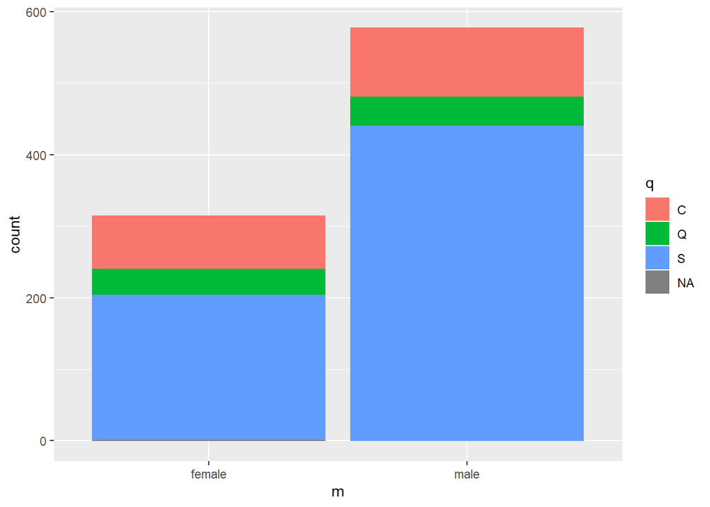

```r
barchartmaker<-function(m,q){data.frame(m,q)%>% ggplot(aes(x=m, color=q, fill=q))+
  geom_bar()}
barchartmaker(out$Sex, out$Embarked)
```

10. Write a function that
- input a data frame
- output all the possible bar charts of a categorical variable filled by another categorical variables where both of the two variables must have the number of categories less than 4.

Check your function on the titanic data

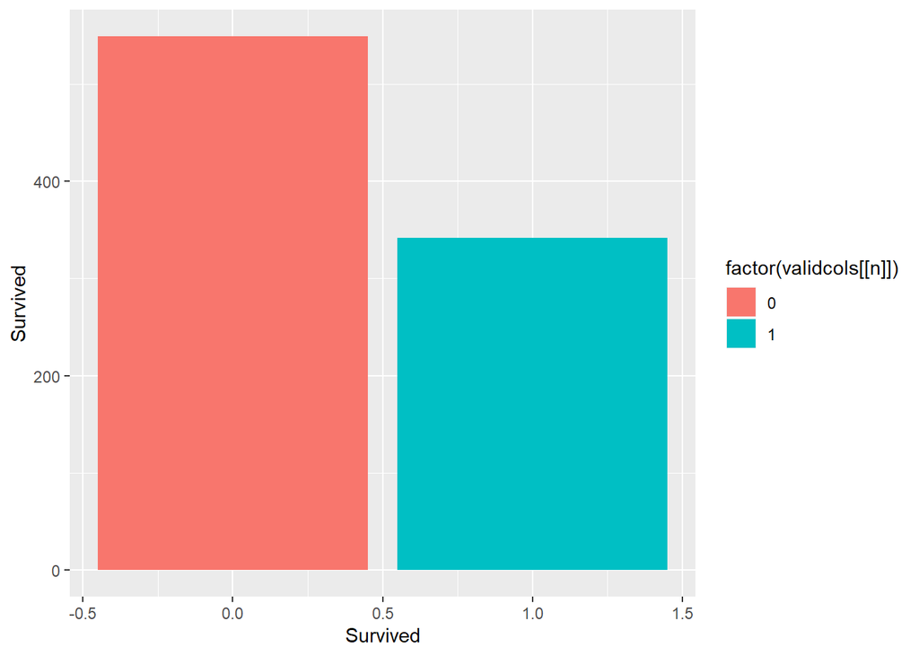

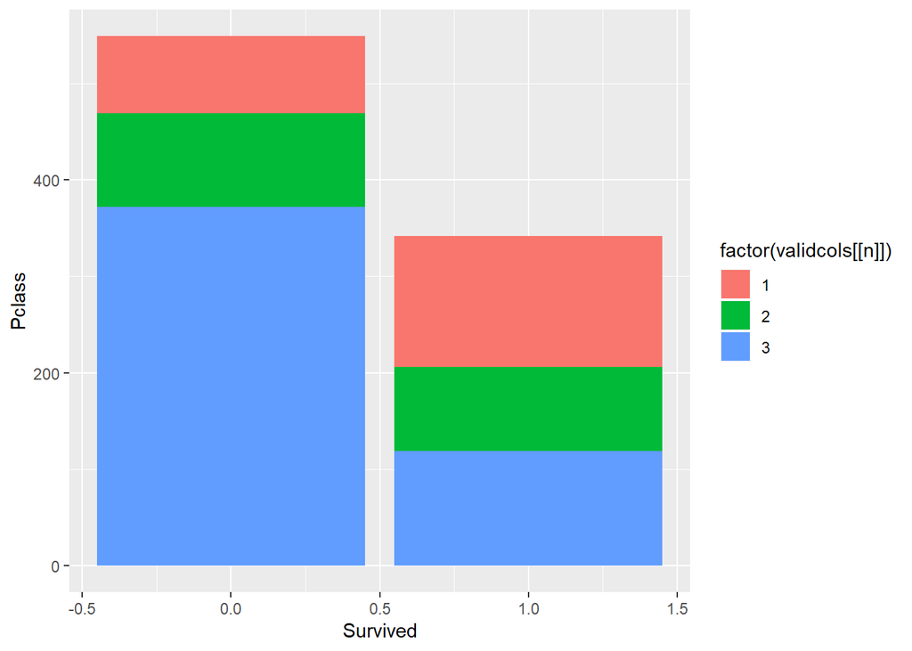

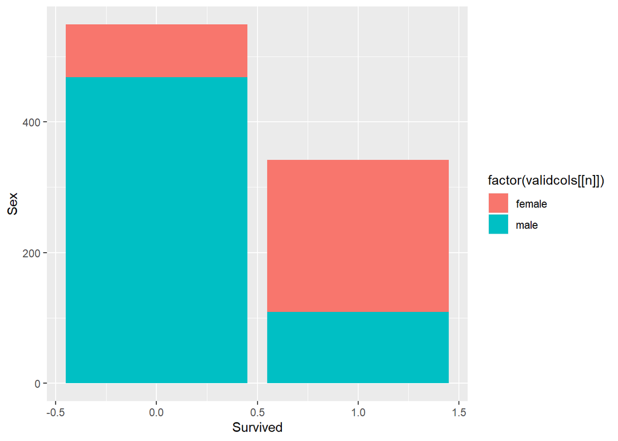

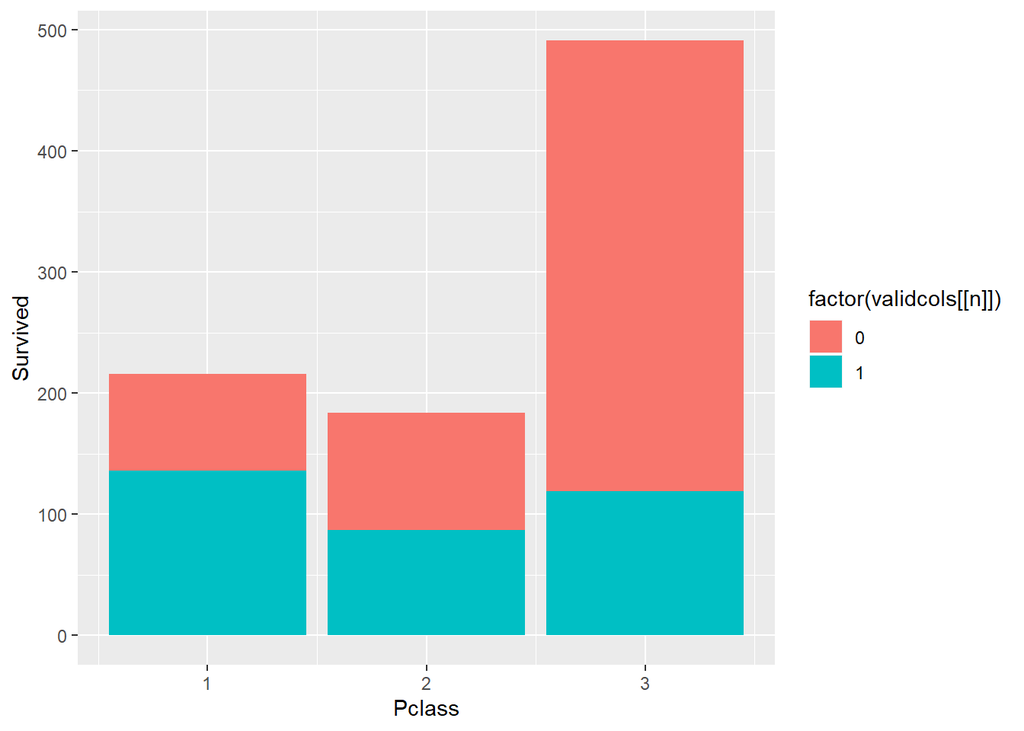

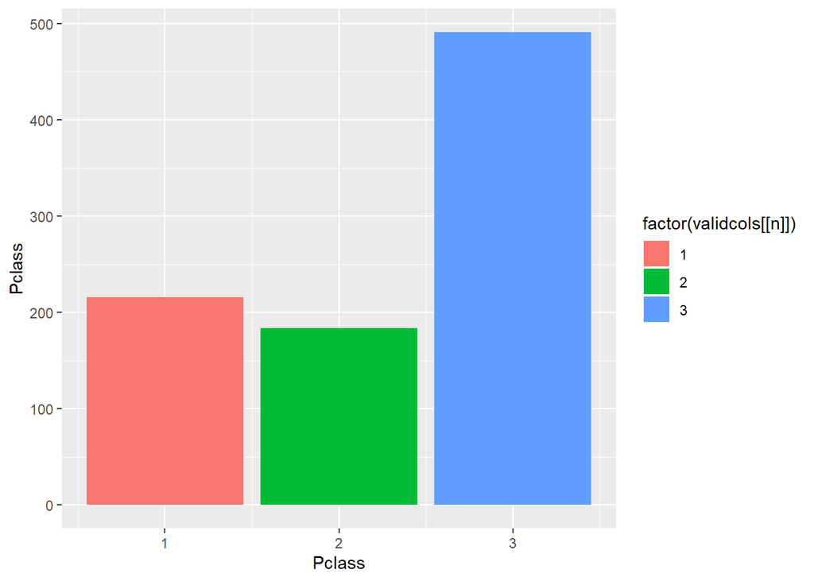

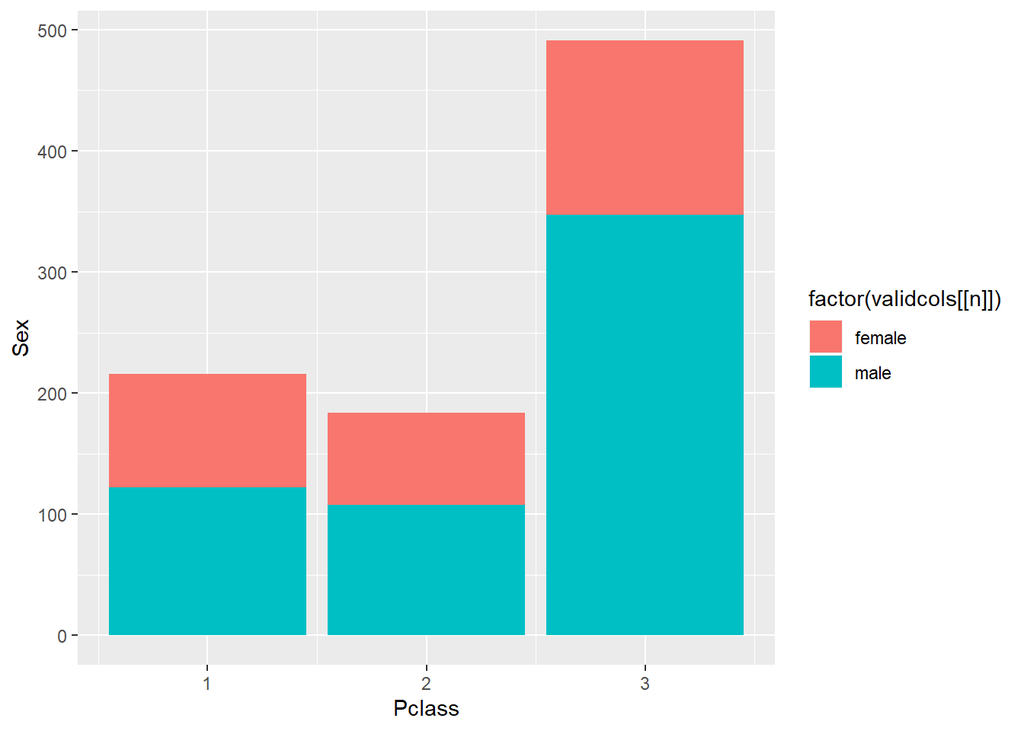

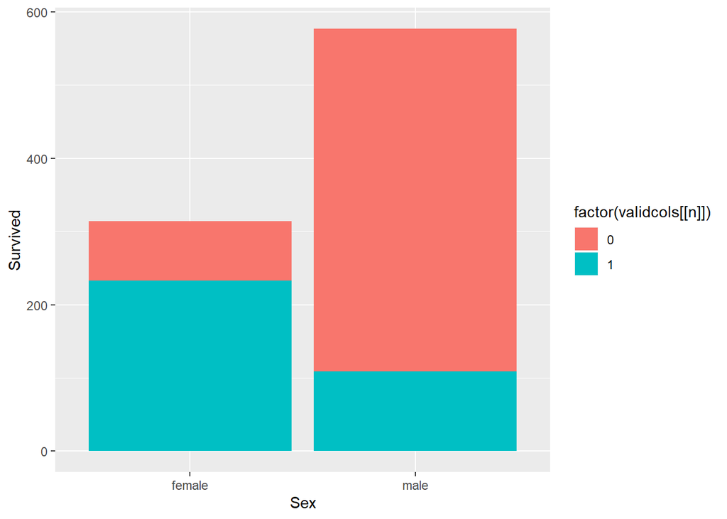

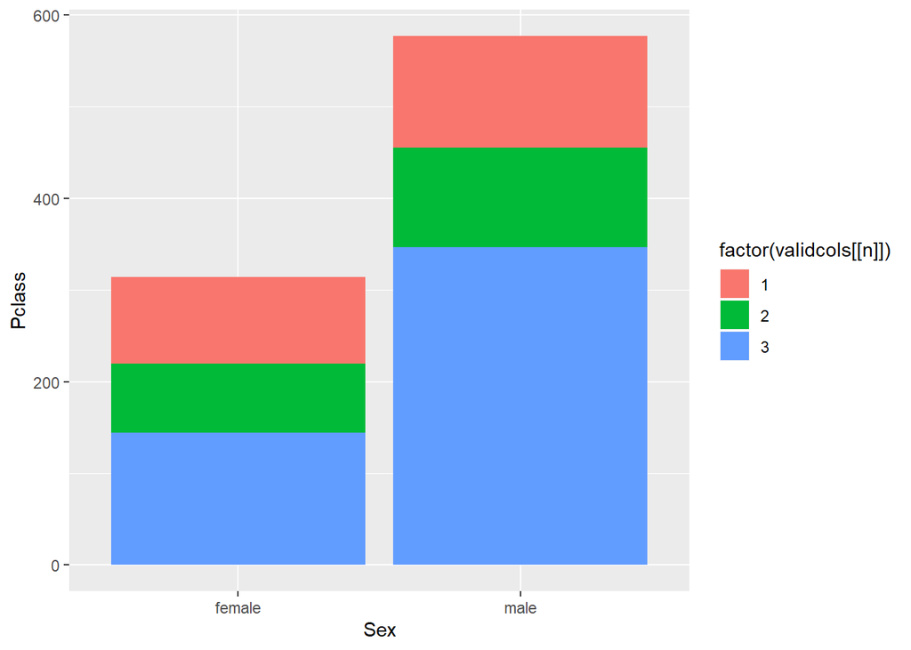

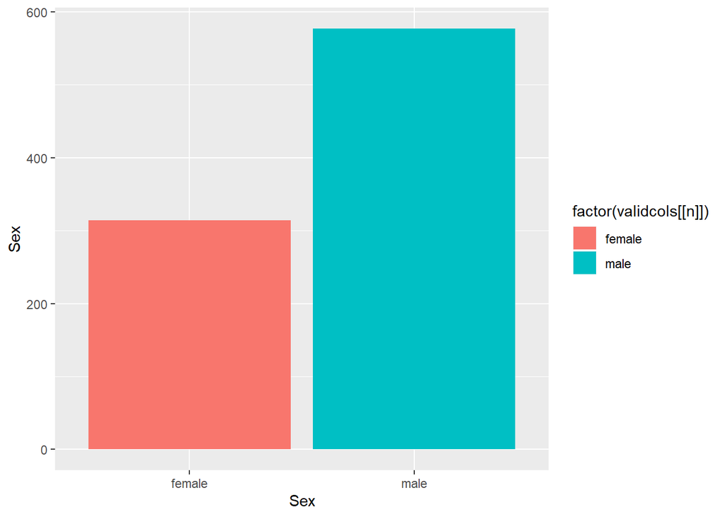

```r
question10<- function(x) {validcols <- x[, sapply(x, function(col) length(unique(col))) < 4]

for (f in 1:length(validcols)) {
  for (n in 1:length(validcols)) {
    plt <- ggplot(validcols, aes(x=validcols[[f]], fill=factor(validcols[[n]])))+
      geom_bar()+
      xlab(names(validcols)[f])+
      ylab(names(validcols)[n])
    print(plt)
  }
}
}
question10(titanic)
```

11. Write a function for a quick visualization that input a (cleaned) data and a number $k$ and output the follows
- If $k=1$, output all the possible bar charts of a categorical variable filled by another categorical variables where both of the two variables must have the number of categories less than 4.
- If $k=2$, output all the possible density curve (using `geom_density`), i.e. density curves of all numeric variables
- If $k=3$, all possible density curves of all numeric variables coloring by a categorical variable with the number of categories less than 4.

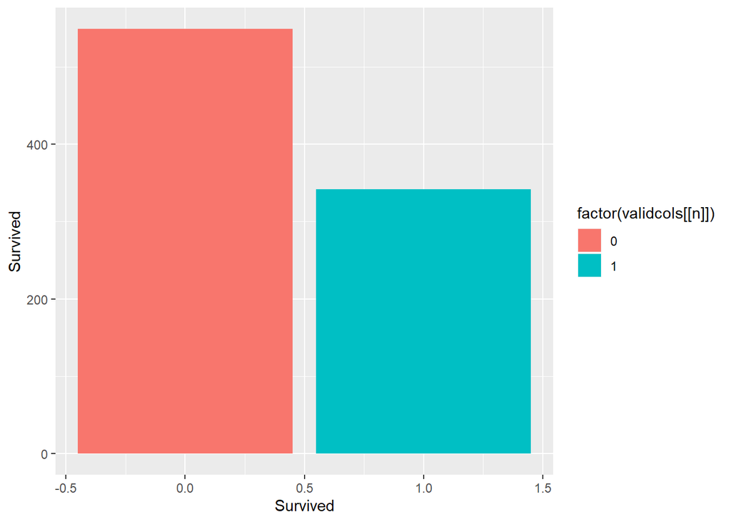

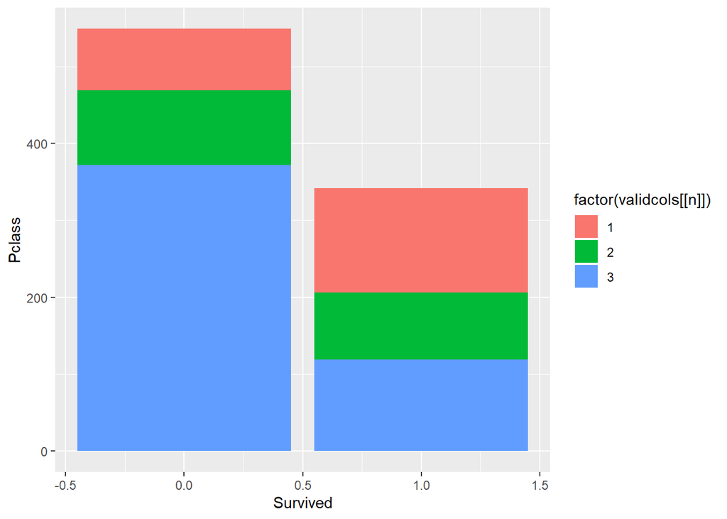

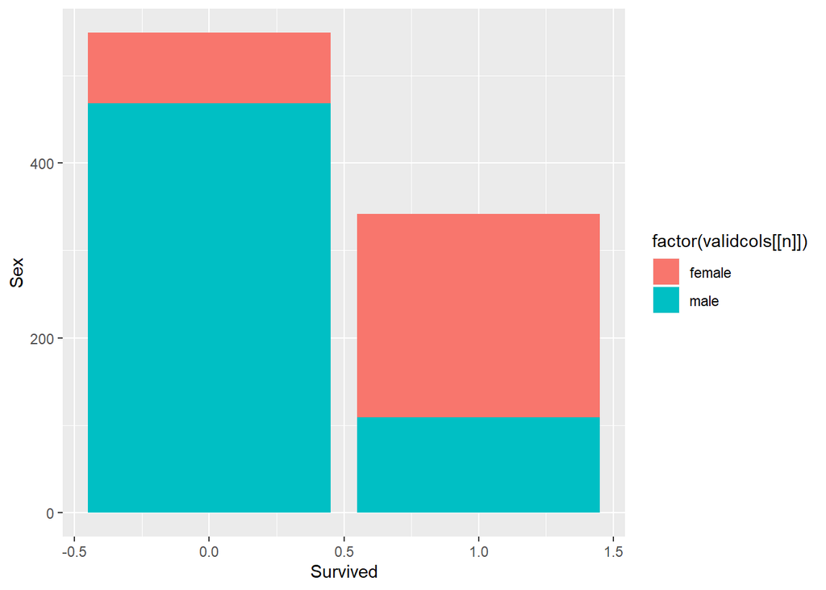

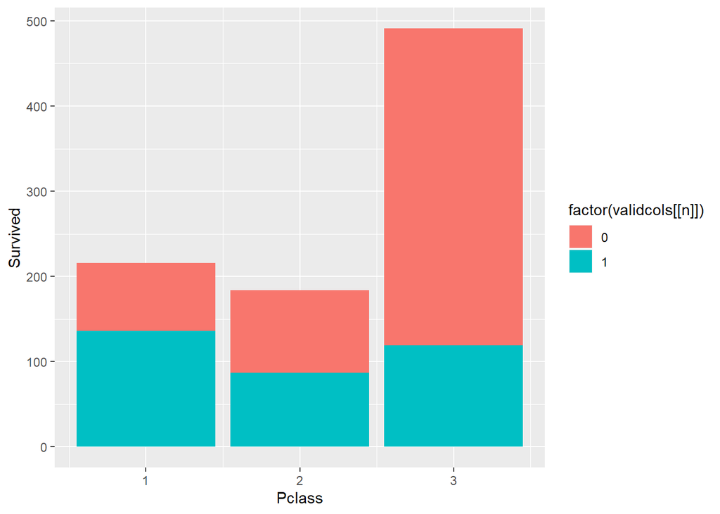

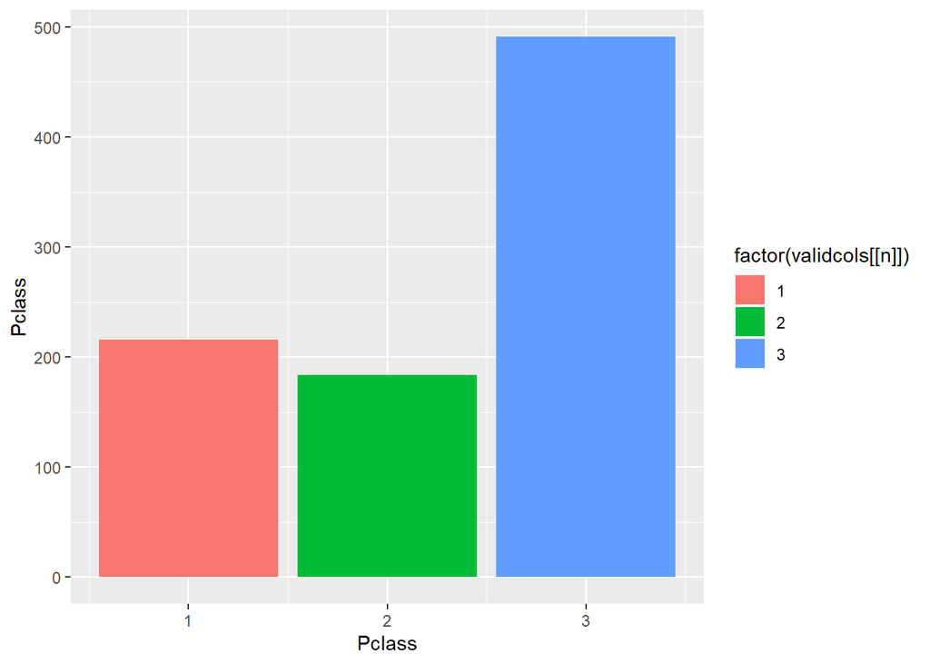

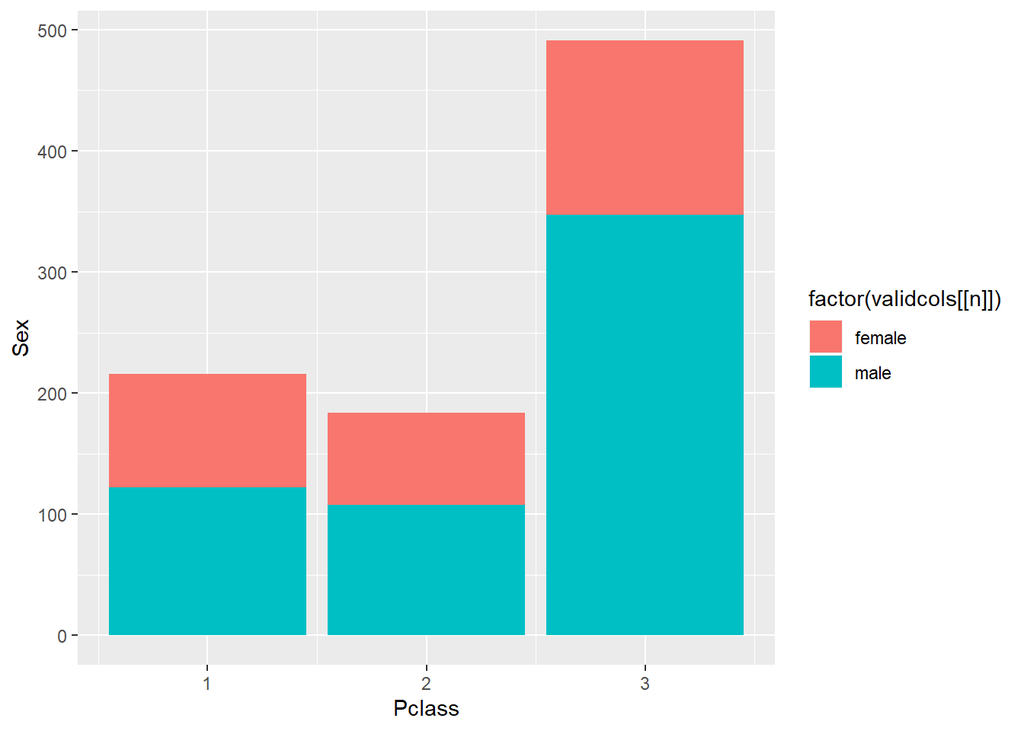

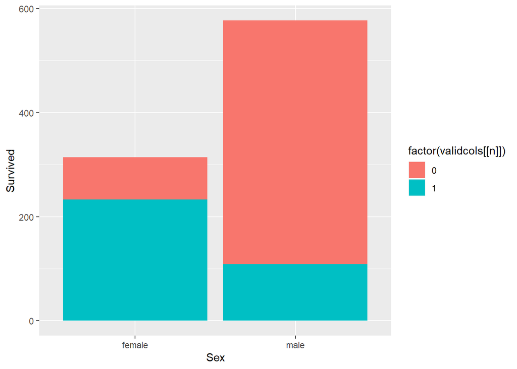

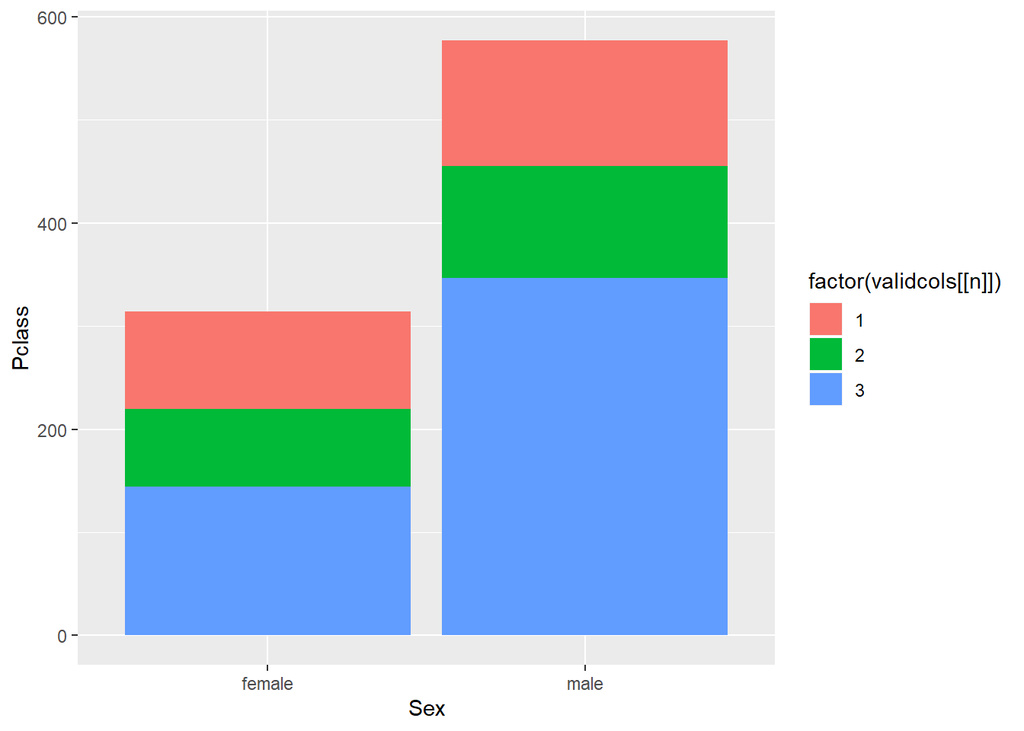

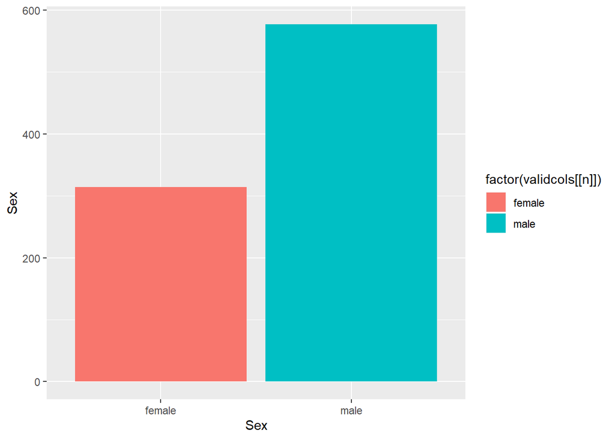

```r
densitybyCategory <- function(x) {
  validcols <- x[, sapply(x, function(col) length(unique(col))) < 4]
  numericCols<-x%>%
    select_if(is.numeric)
  for (f in 1:length(numericCols)) {
    for (n in 1:length(validcols)) {
      plt <- ggplot(validcols, aes(x=numericCols[[f]], color=factor(validcols[[n]])))+
        geom_density()+
      xlab(names(validcols)[n])+
      ylab(names(validcols)[f])
      print(plt)
    }
  }
}

densityFunction <- function(x) {numericCols<-x %>% select_if(is.numeric)
for (f in 1:length(numericCols)) {
    plt <- ggplot(validcols, aes(x=numericCols[[f]]))+
      geom_density()+
      xlab(names(validcols)[f])
    print(plt)
  }
}


question11<-function(z, n){
if(n == 1) {question10(z)}
else if (n == 2) {densityFunction(z)}
else if (n == 3) {densitybyCategory(z)}
else {print("error")}
}

question11(titanic, 1)
```